## Prova di Statistica (CLEA E CLEAM)

Scrivere in stampatello

| COGNOME | $\LARGE\square$ | $\LARGE\square$ | $\LARGE\square$ | $\LARGE\square$ | $\LARGE\square$ | $\LARGE\square$ | $\LARGE\square$ | $\LARGE\square$ | $\LARGE\square$ | $\LARGE\square$ | $\LARGE\square$ | $\LARGE\square$ | $\LARGE\square$ | $\LARGE\square$ | $\LARGE\square$ | $\LARGE\square$ | $\LARGE\square$ | $\LARGE\square$ | $\LARGE\square$ | $\LARGE\square$ |
| --- | --- | --- | --- | --- | --- | --- | --- | --- | --- | --- | --- | --- | --- | --- | --- | --- | --- | --- | --- | --- |
| NOME | $\LARGE\square$ | $\LARGE\square$ | $\LARGE\square$ | $\LARGE\square$ | $\LARGE\square$ | $\LARGE\square$ | $\LARGE\square$ | $\LARGE\square$ | $\LARGE\square$ | $\LARGE\square$ | $\LARGE\square$ | $\LARGE\square$ | $\LARGE\square$ | $\LARGE\square$ | $\LARGE\square$ | $\LARGE\square$ | $\LARGE\square$ | $\LARGE\square$ | $\LARGE\square$ | $\LARGE\square$ |
| Matricola | $\LARGE\square$ | $\LARGE\square$ | $\LARGE\square$ | $\LARGE\square$ | $\LARGE\square$ | $\LARGE\square$ | $\LARGE\square$ | $\LARGE\square$ | $\LARGE\square$ | $\LARGE\square$ | $\LARGE\square$ | $\LARGE\square$ | $\LARGE\square$ | $\LARGE\square$ | $\LARGE\square$ | $\LARGE\square$ | $\LARGE\square$ | $\LARGE\square$ | $\LARGE\square$ | $\LARGE\square$ |

### Esercizio 1

Su un campione di $150$ famiglie residenti in Emilia-Romagna, selezionate in base a composizione e reddito dichiarato, sono stati rilevati gli importi spesi annualmente in connessione a banda larga e dispositivi digitali (valori in centinaia di euro). Qui di seguito è riportata la distribuzione delle frequenze assolute degli importi rilevati.

| $[\text{x}_j,$ | $\text{x}_{j+1})$ | $n_j$ |
| --- | --- | --- |
| 0 | 3 | 38 |
| 3 | 6 | 75 |
| 6 | 12 | 22 |
| 12 | 24 | 15 |
|  |  | 150 |

1.a **(Punti 14/105 $\rightarrow$ 4.1/31)** Disegnare l’istogramma di densità percentuale.

| $[\text{x}_j,$ | $\text{x}_{j+1})$ | $n_j$ | $f_j$ | $b_j$ | $h_j$ |
| --- | --- | --- | --- | --- | --- |
| 0 | 3 | 38 | 0.2533 | 3 | 8.4444 |
| 3 | 6 | 75 | 0.5000 | 3 | 16.6667 |
| 6 | 12 | 22 | 0.1467 | 6 | 2.4444 |
| 12 | 24 | 15 | 0.1000 | 12 | 0.8333 |
|  |  | 150 | 1.0000 | 24 |  |

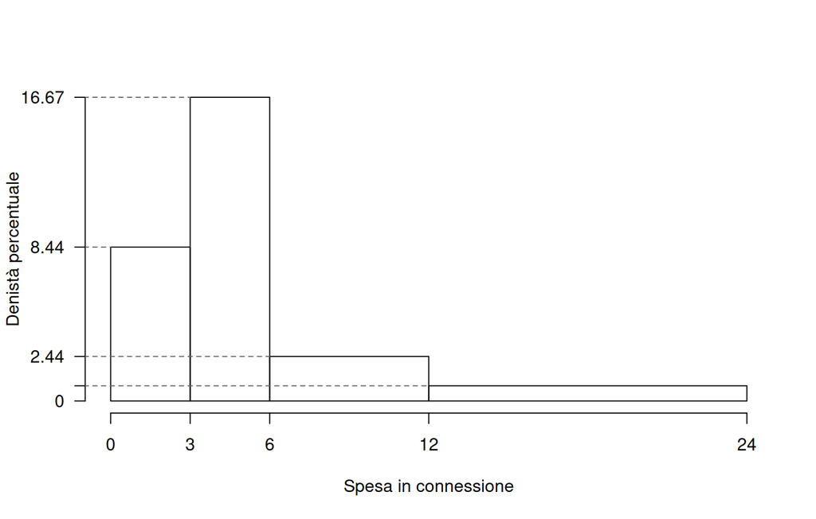

1.b **(Punti 3/105 $\rightarrow$ 0.9/31)** Quante imprese investono tra $x_{0.15}$ il 15-esimo e $x_{0.85}$ l’85-esimo percentile?

$$\begin{eqnarray*}
\%(1.7763<X<9.9545) &=& (3-1.7763)\times h_{1}+ f_{ 2
}\times 100 + (9.9545-6)\times h_{3} \\
&=& (1.2237)\times 8.4444+ ( 0.5 )\times 100 + (3.9545)\times
2.4444 \\
&=& 0.7 \times(100)\\
\#( 1.776 < X < 9.954 ) &\approx& 105
\end{eqnarray*}$$

1.c **(Punti 2/105 $\rightarrow$ 0.6/31)** Che relazione dobbiamo aspettarci tra media, mediana e moda?

1.d **(Punti 2/105 $\rightarrow$ 0.6/31)** Siano $x_1,...,x_n$, $n$ dati tali per cui $\bar x=3$. Posto $y_i = 1.5+0.5\cdot x_i,\forall i$. Per quale valore $y$ la funzione

$$g(y)=\sum_{i=1}^n (y_i- y)^2$$

raggiunge il suo minimo?

### Esercizio 2

2.a **(Punti 14/105 $\rightarrow$ 4.1/31)** Si consideri un’urna che ha 5 palline bianche, 5 nere e 5 verdi. Si estrae 3 volte **con** reinserimento. Sia $X$ la variabile casuale che conta il numero di bianche su 3 estrazioni. Calcolare la probabilità che $X\leq 1$.

$$\begin{eqnarray*}
P( X \leq 1 ) &=& \binom{ 3 }{ 0 } 0.3333 ^{ 0 }(1- 0.3333
)^{ 3 - 0 }+\binom{ 3 }{ 1 } 0.3333 ^{ 1 }(1- 0.3333 )^{ 3 - 1 }
\\ &=& 0.2963+0.4444
\\ &=& 0.7407
\end{eqnarray*}$$

2.b **(Punti 3/105 $\rightarrow$ 0.9/31)** Si consideri un’urna che ha 5 palline bianche, 5 nere e 5 verdi. Si estrae 3 volte **senza** reinserimento. Sia $X$ la variabile casuale che conta il numero di bianche su 3 estrazioni. Calcolare la probabilità che $X\leq 1$.

2.c **(Punti 2/105 $\rightarrow$ 0.6/31)** Sia $X$ una VC definita su $S_X=\{0,1,2,3\}$, posto $Y=2X$ ricavare $S_Y$.

2.d **(Punti 2/105 $\rightarrow$ 0.6/31)** Sia $X$ una VC, e siano $P(X\leq 1)=0.1$, $P(X> 2)=0.1$. Calcolare
$$P(X>2|X>1)$$

$$\begin{eqnarray}
P(X>2|X>1) &=& \frac{P({X>2}\cap {X>1})}{P(X>
1)}\\
&=& \frac{P({X>2})}{P(X> 1)}\\
&=& \frac{0.1}{1-0.1}\\
&=& 0.1111
\end{eqnarray}$$

### Esercizio 3

3.a **(Punti 14/105 $\rightarrow$ 4.1/31)** Siano $X_1,...,X_{100}$, 100 VC IID, $X_i\sim \text{Pois}(\lambda=1)$, posto
$$S_{100} = X_1+ ... +X_{100}$$
Calcolare $P(S_{100}>90)$.

**Teorema del Limite Centrale (somma di Poisson)**

Siano $X_1$,…,$X_n$, $n=100$ VC IID, tc $X_i\sim\text{Pois}(\lambda=1)$$,\forall i$, posto:
$$S_n = X_1 + ... + X_n$$
allora:
$$\begin{eqnarray*}
S_n & \mathop{\sim}\limits_{a}& N(n\lambda,n\lambda) \\
&\sim & N(100\cdot1,100\cdot1) \\
&\sim & N(100,100)
\end{eqnarray*}$$
$$\begin{eqnarray*}
P( \bar X > 90 )
&=& P\left( \frac { \bar X - n\lambda }{
\sqrt{n\lambda} } > \frac { 90 - 100 }{\sqrt{ 100 }} \right) \\
&=& P\left( Z > -1 \right)
\\ &=& 1-P(Z< -1 )\\
&=& 1-(1-\Phi( 1 )) \\ &=& 0.8413
\end{eqnarray*}$$

### Esercizio 4

4.a **(Punti 3/105 $\rightarrow$ 0.9/31)** La VAC Gamma, $X \sim \text{Gamma}(\alpha, \beta)$, è una VC continua, definita su $S_X=\mathbb{R}^+$, $\alpha>0$ e $\beta>0$, con densità che per $\alpha > 1$ assume una forma campanulare con asimmetria positiva, mentre per $\alpha = 1$ coincide con l’esponenziale e per $\alpha < 1$ è fortemente asimmetrica con una concentrazione di densità vicino allo zero. Il parametro $\beta$ controlla la dispersione. La distribuzione Gamma è usata per modellare tempi di attesa o grandezze cumulative sempre positive.

Si consideri un campione $X_1,\dots,X_n \sim \text{Gamma}(\alpha,\beta)$ IID. Lo stimatore di massima verosimiglianza per $\beta$ è
$$\hat\beta = \frac {\bar X}\alpha,\qquad \text{dove $\bar X$ è la media
campionaria}$$
Sapendo che
$$E(\hat\beta) = \beta~~~ \text{ e }~~~ V(\hat\beta) =
\frac{\beta^2}{\alpha \cdot n},$$
$\hat\beta$ è consistente?

Poiché $\hat\beta$ è asintoticamente corretto (cioè $E(\hat\beta) = \beta$) e la sua varianza tende a zero:

$$\lim_{n \to \infty} V(\hat\beta) = \lim_{n \to \infty}
\frac{\beta^2}{\alpha n} = 0,$$

segue che:

$$\lim_{n \to \infty} MSE(\hat\beta) = 0,$$

quindi $\hat\beta$ è **consistente**.

4.b **(Punti 3/105 $\rightarrow$ 0.9/31)** Sia $\hat\theta$ uno stimatore di massima verosimiglianza per $\theta$ qual è la sua distribuzione asintotica?

4.c **(Punti 3/105 $\rightarrow$ 0.9/31)** Definire la significatività e la potenza di un test.

4.d **(Punti 3/105 $\rightarrow$ 0.9/31)** Si è lanciata una moneta 100 volte per testare se è una moneta ben bilanciata, si è sono ottenuti 74 test su 100 lanci. Posto a test
$$\begin{cases}
H_0: \pi = \frac 12\\
H_1: \pi\ne\frac 12
\end{cases}$$
si è ottenuto un $p_\text{value}=0.000002$. Cosa si può concludere, la moneta è bilanciata oppure no?

Poiché il $p_\text{value} = 0.000002$ è molto più piccolo di qualsiasi livello di significatività convenzionale (ad esempio $\alpha = 0.05$, $0.01$, $0.001$), si rifiuta l’ipotesi nulla $H_0$.

Ci sono fortissime evidenze contro l’ipotesi che la moneta sia bilanciata. Quindi non si può ritenere che la moneta sia equa.

### Esercizio 5

In un’indagine condotta sui 52 stati USA (i 50 stati, il District of Columbia e Porto Rico), sono stati raccolti dati da $n = 52$ stati. Per ciascuno stato si è rilevata la percentuale di popolazione sotto la soglia federale di povertà ($X$) e il tasso di natalità ($Y$, in numero medio annuo di nati ogni 1000 abitanti). Si vuole studiare l’associazione tra incidenza della povertà e dinamica demografica nei diversi contesti statali.

Si osservano le seguenti statistiche: $\sum_{i=1}^{52}x_i=387.3$, $\sum_{i=1}^{52}y_i=166.7$, $\sum_{i=1}^{52}x_i^2=2978.53$, $\sum_{i=1}^{52}y_i^2=540.47$ e $\sum_{i=1}^{52}x_iy_i=1224.22$.

5.a **(Punti 14/105 $\rightarrow$ 4.1/31)** Per il New Hampshire si è osservato $x_{NH}=5.4$ e $y_{NH}=3.6$, stimare il modello di regressione dove $Y$ viene spiegata da $X$ e calcolare il residuo per i dati del New Hampshire

$$\begin{eqnarray*}
\bar x &=&\frac 1 n\sum_{i=1}^n x_i = \frac {1}{ 52
} 387.3 = 7.448 \\
\bar y &=&\frac 1 n\sum_{i=1}^n y_i = \frac {1}{ 52
} 166.7 = 3.206 \\
\hat\sigma_X^2&=&\frac 1 n\sum_{i=1}^n x_i^2-\bar
x^2=\frac {1}{ 52 } 2979 - 7.4481 ^2= 1.806 \\
\hat\sigma_Y^2&=&\frac 1 n\sum_{i=1}^n y_i^2-\bar
y^2=\frac {1}{ 52 } 540.5 - 3.2058 ^2= 0.1167 \\
\text{cov}(X,Y)&=&\frac 1 n\sum_{i=1}^n x_i~y_i-\bar
x\bar y=\frac {1}{ 52 } 1224 - 7.4481 \cdot 3.2058 = -0.3341 \\
\hat\beta_1 &=&
\frac{\text{cov}(X,Y)}{\hat\sigma_X^2} \\
&=& \frac{ -0.3341 }{ 1.806 } = -0.1851 \\
\hat\beta_0 &=& \bar y - \hat\beta_1 \bar x\\
&=& 3.206 - (-0.1851) \times 7.4481 =
4.584
\end{eqnarray*}$$
$$\begin{eqnarray*}
\hat y_i &=&\hat\beta_0+\hat\beta_1 x_i=\\
&=& 4.584 + (-0.1851) \times 5.4 = 3.585 \\
\hat \varepsilon_i &=& y_i-\hat y_i\\
&=& 3.6 - 3.585 = 0.01523
\end{eqnarray*}$$

5.b **(Punti 3/105 $\rightarrow$ 0.9/31)** Il modello si adatta bene ai dati?

$$\begin{eqnarray*}
r&=&\frac{\text{cov}(X,Y)}{\sigma_X\sigma_Y}=\frac{ -0.3341 }{
1.344 \times 0.3416 }= -0.7279 \\r^2&=& 0.5298 < 0.75
\end{eqnarray*}$$
Il modello **non** si adatta bene ai dati.

5.c **(Punti 2/105 $\rightarrow$ 0.6/31)** Qual è la differenza tra interpolazione ed estrapolazione?

5.d **(Punti 2/105 $\rightarrow$ 0.6/31)** Cosa significa che $r$ è invariante ai cambiamenti di scala?

5.e **(Punti 2/105 $\rightarrow$ 0.6/31)** Se nel modello di regressione stimato nel punto 5.a trasformassimo l’indice di povertà $X$ in un tasso di ricchezza $W=100-X$, quanto varrebbe $r_{WY}$?

5.f **(Punti 14/105 $\rightarrow$ 4.1/31)** Testare l’ipotesi che $\beta_0$ sia uguale a 0, contro l’alternativa che sia diverso per $\alpha=0.1,0.05,0.01,0.001$ e dare una valutazione approssimativa del $p_\text{value}$ (ad esempio il $p_\text{value}$ è minore di 0.001, compreso tra 0.05 e tra 0.01, ecc.).

$\fbox{A}$ FORMULAZIONE DELLE IPOTESI

$$\begin{cases}
H_0: \beta_0 = \beta_{0;H_0}=0 \\
H_1: \beta_0 \neq \beta_{0;H_0}=0
\end{cases}$$

$\fbox{B}$ SCELTA E CALCOLO STATISTICA-TEST, $T$ Test su un coefficiente di regressione: $\Rightarrow$ t-Test.

$$\begin{eqnarray*}
\hat{\sigma_\varepsilon}^2&=&(1-r^2)\hat\sigma_Y^2\\
&=& (1- 0.5298 )\times 0.1167 \\
&=& 0.0549 \\
S_\varepsilon^2 &=& \frac{n} {n-2}
\hat{\sigma_\varepsilon}^2\\
&=& \frac{ 52 } { 52 -2} \hat{\sigma_\varepsilon}^2 \\
&=& \frac{ 52 } { 52 -2} \times 0.0549 = 0.0571
\end{eqnarray*}$$

E quindi
$$\begin{eqnarray*}
V(\hat\beta_{0}) &=& \sigma_{\varepsilon}^{2} \left( \frac{1}
{n} + \frac{\bar{x}^{2}} {n \hat{\sigma}^{2}_{X}} \right)\\
\widehat{V(\hat\beta_{0})} &=& S_{\varepsilon}^{2}\left(
\frac{1} {n} + \frac{\bar{x}^{2}} {n \hat{\sigma}^{2}_{X}} \right)\ \\
&=& 0.0571 \times\left( \frac{1} { 52 } + \frac{ 7.448 ^{2}}
{ 52 \times 1.806 } \right)\\
\widehat{SE(\hat\beta_{0})} &=& \sqrt{ 0.0348 }\\
&=& 0.1865
\end{eqnarray*}$$
$$\begin{eqnarray*}
\frac{\hat\beta_{ 0 } - \beta_{ 0 ;H_0}} {\widehat{SE(\hat\beta_{ 0
})}}&\sim&t_{n-2}\\
t_{\text{obs}}
&=& \frac{ ( 4.584 - 0 )} { 0.1866 }
= 24.57 \, .
\end{eqnarray*}$$

$\fbox{C}$ CONCLUSIONE

Siccome $H_1$ è bilaterale, considereremo $\alpha/2$, anziché $\alpha$

$\alpha=0.1, 0.05, 0.01, 0.001$ e quindi $\alpha/2=0.05, 0.025, 0.005, 0.0005$

I valori critici sono

$t_{52-2;0.05}=1.6759$; $t_{52-2;0.025}=2.0086$; $t_{52-2;0.005}=2.6778$; $t_{52-2;0.0005}=3.496$

Siccome $|t_\text{obs}|=24.5688>3.496$, quindi **rifiuto** $H_0$ sotto all’1‰,

$p_\text{value}<0.001$, *estremamente significativo* $\fbox{***}$.

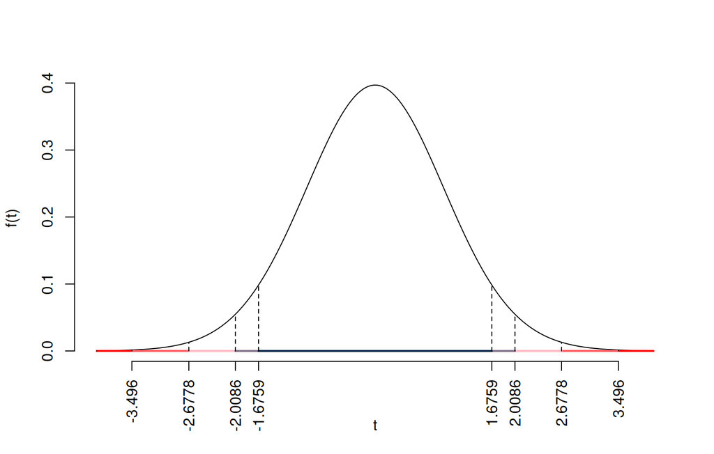

Il $p_{\text{value}}$ è

$$p_{\text{value}} =
P(|T_{52-2}|>|24.57|)=2P(T_{52-2}>24.57)=0e+00$$

Attenzione il calcolo del $p_\text{value}$ con la $T$ è puramente illustrativo e non può essere riprodotto senza una calcolatrice statistica adeguata.
$$0 < p_\text{value}= 0e+00 \leq 0.001$$

## Prova di Statistica (CLEA E CLEAM)

Scrivere in stampatello

| COGNOME | $\LARGE\square$ | $\LARGE\square$ | $\LARGE\square$ | $\LARGE\square$ | $\LARGE\square$ | $\LARGE\square$ | $\LARGE\square$ | $\LARGE\square$ | $\LARGE\square$ | $\LARGE\square$ | $\LARGE\square$ | $\LARGE\square$ | $\LARGE\square$ | $\LARGE\square$ | $\LARGE\square$ | $\LARGE\square$ | $\LARGE\square$ | $\LARGE\square$ | $\LARGE\square$ | $\LARGE\square$ |
| --- | --- | --- | --- | --- | --- | --- | --- | --- | --- | --- | --- | --- | --- | --- | --- | --- | --- | --- | --- | --- |
| NOME | $\LARGE\square$ | $\LARGE\square$ | $\LARGE\square$ | $\LARGE\square$ | $\LARGE\square$ | $\LARGE\square$ | $\LARGE\square$ | $\LARGE\square$ | $\LARGE\square$ | $\LARGE\square$ | $\LARGE\square$ | $\LARGE\square$ | $\LARGE\square$ | $\LARGE\square$ | $\LARGE\square$ | $\LARGE\square$ | $\LARGE\square$ | $\LARGE\square$ | $\LARGE\square$ | $\LARGE\square$ |
| Matricola | $\LARGE\square$ | $\LARGE\square$ | $\LARGE\square$ | $\LARGE\square$ | $\LARGE\square$ | $\LARGE\square$ | $\LARGE\square$ | $\LARGE\square$ | $\LARGE\square$ | $\LARGE\square$ | $\LARGE\square$ | $\LARGE\square$ | $\LARGE\square$ | $\LARGE\square$ | $\LARGE\square$ | $\LARGE\square$ | $\LARGE\square$ | $\LARGE\square$ | $\LARGE\square$ | $\LARGE\square$ |

### Esercizio 1

Su un campione di $150$ famiglie residenti in Emilia-Romagna, selezionate in base a composizione e reddito dichiarato, sono stati rilevati gli importi spesi annualmente in connessione a banda larga e dispositivi digitali (valori in centinaia di euro). Qui di seguito è riportata la distribuzione delle frequenze relative degli importi rilevati.

| $[\text{x}_j,$ | $\text{x}_{j+1})$ | $f_j$ |
| --- | --- | --- |
| 0 | 3 | 0.2 |
| 3 | 5 | 0.5 |
| 5 | 15 | 0.2 |
| 15 | 30 | 0.1 |
|  |  | 1.0 |

1.a **(Punti 14/105 $\rightarrow$ 4.1/31)** Individuare l’intervallo modale.

| $[\text{x}_j,$ | $\text{x}_{j+1})$ | $n_j$ | $f_j$ | $b_j$ | $h_j$ |
| --- | --- | --- | --- | --- | --- |
| 0 | 3 | 30 | 0.2 | 3 | 6.6667 |
| 3 | 5 | 75 | 0.5 | 2 | 25.0000 |
| 5 | 15 | 30 | 0.2 | 10 | 2.0000 |
| 15 | 30 | 15 | 0.1 | 15 | 0.6667 |
|  |  | 150 | 1.0 | 30 |  |

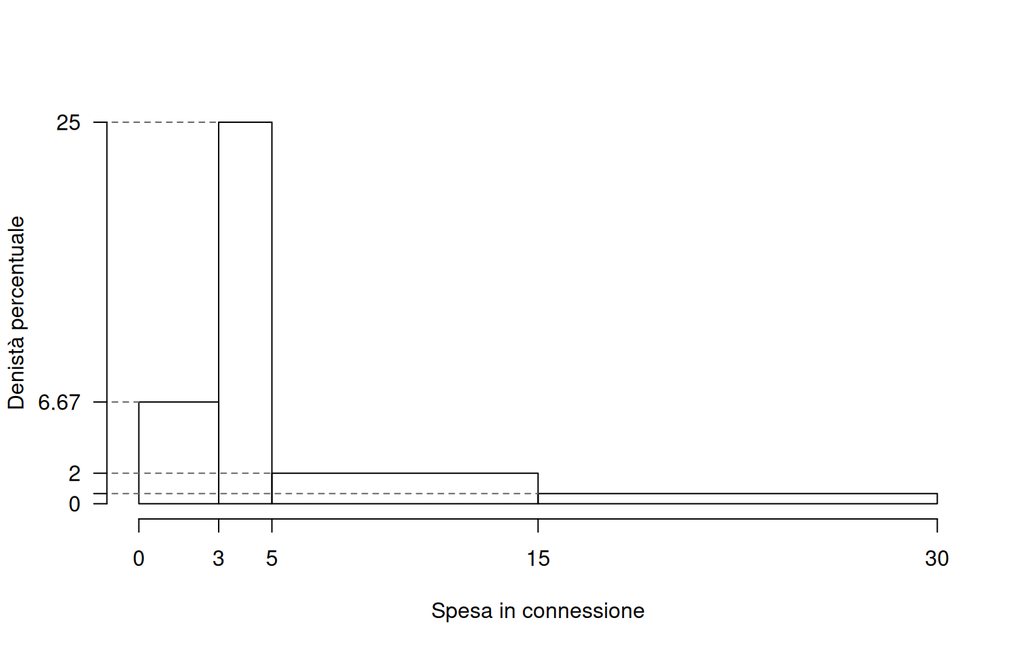

1.b **(Punti 3/105 $\rightarrow$ 0.9/31)** Quante imprese investono tra $x_{0.25}$ il 25-esimo e $x_{0.75}$ il 75-esimo percentile?

$$\begin{eqnarray*} \%(3.2<X<7.5)
&=& (5-3.2)\times h_{2}+ (7.5-5)\times h_{3} \\
&=& (1.8)\times 25+ (2.5)\times 2 \\
&=& 0.5 \times(100)\\
\#( 3.2 < X < 7.5 ) &\approx& 75
\end{eqnarray*}$$

1.c **(Punti 2/105 $\rightarrow$ 0.6/31)** La media è pari a $\bar x=6.48$, senza disegnare l’istogramma, che forma distributiva dobbiamo aspettarci?

1.d **(Punti 2/105 $\rightarrow$ 0.6/31)** La spesa media della regione Emilia-Romagna, calcolata su 150 famiglie è pari $\bar x_{ER}=6.48$, quella della Lombardia, calcolata su 165 famiglie è pari $\bar x_{L}=6.6$, mentre quella del Veneto, calcolata su 145 famiglie è pari $\bar x_{V}=5.28$. Qual è la spesa media complessiva delle tre regioni?

Per trovare la spesa media delle tre regioni aggregate, dobbiamo considerare sia le medie delle singole regioni sia il numero di famiglie su cui sono state calcolate. La formula per la media aggregata $\bar{x}_{agg}$ è:

$$\begin{eqnarray}
\bar{x}_{agg} &=& \frac{n_{ER} \bar{x}_{ER} + n_{L}
\bar{x}_{L} + n_{V} \bar{x}_{V}}{n_{ER} + n_{L} + n_{V}}\\
&=& \frac{150\cdot6.48+165\cdot6.6+145\cdot5.28}{150+165+145}\\
&=& 6.1448
\end{eqnarray}$$

Dove:

- $n_{ER}$ è il numero di famiglie in Emilia-Romagna
- $n_{L}$ è il numero di famiglie in Lombardia
- $n_{V}$ è il numero di famiglie in Veneto
- $\bar{x}_{ER}$, $\bar{x}_{L}$, $\bar{x}_{V}$ sono le spese medie delle rispettive regioni

### Esercizio 2

2.a **(Punti 14/105 $\rightarrow$ 4.1/31)** Sia $X$ il numero di treni in ritardo nella stazione di Bologna Centrale alle 17, $X\sim\text{Pois}(4.3)$. Calcolare la probabilità che $X\geq 2$.

$$\begin{eqnarray*}
P( X \geq 2 ) &=& 1-P( X < 2 )
\\ &=& 1-\left( \frac{ 4.3 ^{ 0 }}{ 0 !}e^{- 4.3
}+\frac{ 4.3 ^{ 1 }}{ 1 !}e^{- 4.3 }
\right)\\ &=& 1-( 0.0136+0.0583
)\\ &=& 1- 0.0719
\\ &=& 0.9281
\end{eqnarray*}$$

2.b **(Punti 3/105 $\rightarrow$ 0.9/31)** Sia $X\sim\text{Pois}(4.3)$, posto $A=\{X\geq 2\}$, $B=\{X\geq 1\}$, calcolare $P(A|B)$.

$$\begin{eqnarray}
P(B) &=& 0.9864\\
P(A\cap B) &=& P( \{X \geq 1\} \cap \{X \geq 2\})\\
&=& P( X \geq 2)\\
&=& 0.9281\\
P(A|B) &=& \frac{P(A\cap B)}{P(B)}\\
&=& \frac{0.9281}{0.9864}\\
&=& 0.9409
\end{eqnarray}$$

2.c **(Punti 2/105 $\rightarrow$ 0.6/31)** Sia $X$ una variabile casuale con supporto $S_X=\{-1,0,1\}$. Posto $Y=1+2\cdot X$, ricavare il supporto di $Y$, $S_Y$.

$$S_Y=\{1+2\cdot (-1),1+2\cdot 0+1+2\cdot (+1)\}=\{-1,1,3\}$$

2.d **(Punti 2/105 $\rightarrow$ 0.6/31)** Sia $X$ una variabile casuale tale che $P(X>1.5)=0.9$ e $P(X>3.5)=0.1$, calcolare $P(X\leq 1.5|X\leq 3.5)$.

$$P(X\leq 1.5|X\leq 3.5) = \frac{0.1}{0.9}=0.1111$$

### Esercizio 3

3.a **(Punti 14/105 $\rightarrow$ 4.1/31)** Siano $X_1,...,X_{100}$, 100 VC IID, $X_i\sim \text{Pois}(\lambda=1)$, posto
$$\bar X=\frac{S_{100}}{100} = \frac{X_1+ ... +X_{100}}{100}$$
Calcolare $P(\bar X>0.9)$.

**Teorema del Limite Centrale (media di Poisson)**

Siano $X_1$,…,$X_n$, $n=100$ VC IID, tc $X_i\sim\text{Pois}(\lambda=1)$$,\forall i$, posto:
$$\bar X=\frac{S_n}n = \frac{X_1 + ... + X_n}n$$
allora:
$$\begin{eqnarray*}
\hat\pi & \mathop{\sim}\limits_{a}& N(\lambda,\lambda/n) \\
&\sim & N\left(1,\frac{1}{100}\right) \\
&\sim & N(1,0.01)
\end{eqnarray*}$$
$$\begin{eqnarray*}
P( \bar X > 0.9 )
&=& P\left( \frac { \bar X - \lambda }{
\sqrt{\lambda/n} } > \frac { 0.9 - 1 }{\sqrt{ 0.01 }} \right) \\
&=& P\left( Z > -1 \right)
\\ &=& 1-P(Z< -1 )\\
&=& 1-(1-\Phi( 1 )) \\ &=& 0.8413
\end{eqnarray*}$$

### Esercizio 4

4.a **(Punti 3/105 $\rightarrow$ 0.9/31)** Si consideri il modello normale $X\sim N(\mu,\sigma^2)$. Sia $\hat\mu$ lo stimatore di massima verosimiglianza per $\sigma^2$

$$\hat\sigma^2 = \frac 1n \sum_{i=1}^n (X_i-\hat\mu)^2$$

sapendo che

$$V(\hat\sigma^2)= \frac{2\sigma^4}n$$

Dimostrare la consistenza di $\hat\sigma^2$

$$\begin{eqnarray}
E(\hat\sigma^2)&=& \frac{n-1}{n}\sigma^2\\
V(\hat\sigma^2)&=& \frac{2\sigma^4}n\\
MSE(\hat\sigma^2) &=&
V(\hat\sigma^2)+\left(E(\hat\sigma^2)-\sigma^2\right)^2\\
&=& \frac{2\sigma^4}n +
\left(\frac{n-1}{n}\sigma^2-\sigma^2\right)^2
\end{eqnarray}$$
Siccome $\hat\sigma^2$ è asintoticamente corretto e la sua varianza va a zero con $n$, allora
$$\begin{eqnarray}
\lim_{n\to\infty} E(\hat\sigma^2) & =&
\lim_{n\to\infty}\frac{n}{n-1}\sigma^2=\sigma^2\\
\lim_{n\to\infty} V(\hat\sigma^2) &=&
\lim_{n\to\infty}\frac{2\sigma^4}n=0\\
\end{eqnarray}$$
allora
$$\lim_{n\to\infty} MSE(\hat\sigma^2) = 0$$

4.b **(Punti 3/105 $\rightarrow$ 0.9/31)** Siano $h_1$ e $h_2$ due stimatori per $\theta$, cosa significa che $h_1$ è più efficiente di $h_2$?

4.c **(Punti 3/105 $\rightarrow$ 0.9/31)** Siano $T_1$ e $T_2$ due test per lo stesso sistema di ipotesi con la stessa significatività $\alpha$, siano $\beta_1$ la probabilità di errore di secondo tipo del test $T_1$ e $\beta_2$ la probabilità di errore di secondo tipo del test $T_2$. Cosa significa dire che $T_1$ è più potente di $T_2$?

Sotto ipotesi di omogeneità, si è testata l’ipotesi che il consumo medio sia uguale tra nord e sud, contro l’alternativa che sia maggiore al nord,
$$\begin{cases}
H_0: \mu_\text{N} = \mu_\text{S} \\
H_1: \mu_\text{N} > \mu_\text{S}
\end{cases}$$
è risultato $p_{\text{value}} = 0.002161$. Possiamo concludere che il consumo medio al nord sia maggiore di quello al sud? Perché?

### Esercizio 5

5.a **(Punti 4/105 $\rightarrow$ 1.2/31)** Su un campione di $n = 80$ comuni dell’area industriale compresa tra Bologna e Modena, è stato rilevato se il comune abbia attivato uno sportello digitale per l’accesso ai servizi sociali. Lo studio ha mostrato che 56 comuni su 80 (il 70% del campione) hanno attivato questo servizio.

Costruire un intervallo di confidenza al 95% per $\pi$, la quota di comuni dell’area Bologna–Modena che hanno attivato uno sportello digitale per i servizi sociali.

$1-\alpha =0.95$ e quindi $\alpha=0.05\rightarrow \alpha/2=0.025$

$$\hat\pi = \frac{S_n}n = \frac{ 56 }{ 80 }= 0.7$$

$$\begin{eqnarray*}
Idc: & & \hat\pi \pm z_{\alpha/2} \times
\sqrt{\frac{\hat\pi(1-\hat\pi)}{n}} \\
& & 0.7 \pm 1.96 \times \sqrt{\frac{ 0.7 (1- 0.7 )}{ 80
}} \\
& & 0.7 \pm 1.96 \times 0.05123 \\
& & [ 0.5996 , 0.8004 ]
\end{eqnarray*}$$

5.b **(Punti 10/105 $\rightarrow$ 3/31)** Un’indagine condotta a livello nazionale ha mostrato che la percentuale di comuni con sportello digitale per i servizi sociali è pari all’80%. Testare l’ipotesi che nella zona Bologna–Modena la quota sia uguale a quella nazionale contro l’alternativa che sia **minore**. Risolvere con il $p_\text{value}$ e confrontarlo per $\alpha = 0.1,\ 0.05,\ 0.01,\ 0.001$.

**Test $Z$ per una proporzione**

La stima
$$\hat\pi=\frac { 56 } { 80 }=
0.7$$

$\fbox{A}$ FORMULAZIONE DELLE IPOTESI

$$\begin{cases}
H_0: \pi = \pi_0=0.8 \\
H_1: \pi < \pi_0=0.8
\end{cases}$$

$\fbox{B}$ SCELTA E CALCOLO STATISTICA-TEST, $Z$ Test Binomiale per $n$ grande: $\Rightarrow$ z-Test.

$$\begin{eqnarray*}
\frac{\hat\pi - \pi_{0}} {\sqrt
{\pi_0(1-\pi_0)/\,n}}&\sim&N(0,1)\\
z_{\text{obs}}
&=& \frac{ ( 0.7 - 0.8 )} {\sqrt{ 0.8 (1- 0.8 )/ 80 }}
= -2.236 \,.
\end{eqnarray*}$$

$\fbox{C}$ CONCLUSIONE

Il $p_{\text{value}}$ è

$$p_{\text{value}} =
P(Z<-2.24)=0.012674$$

$$0.01 < p_\text{value}= 0.012674 \leq 0.05$$

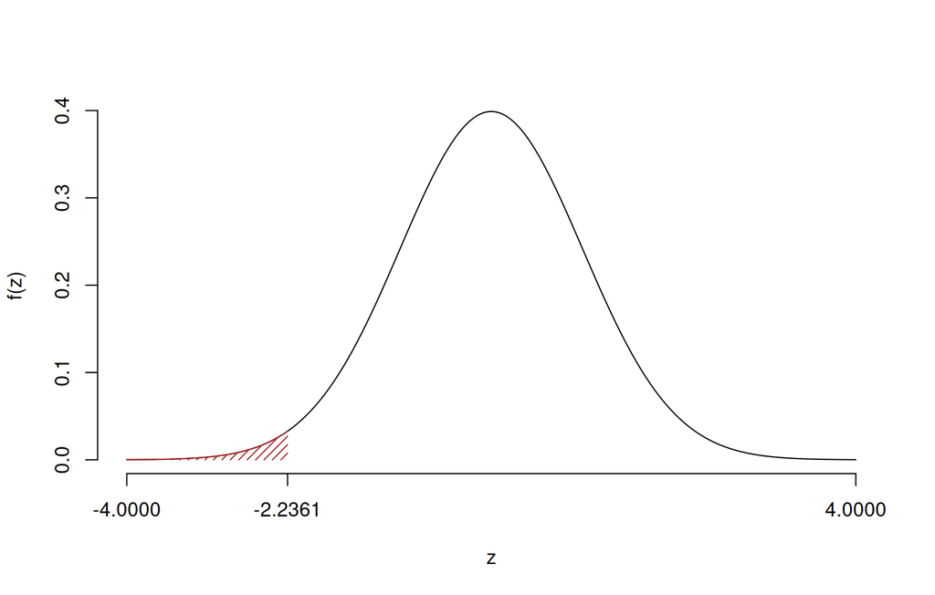

**Rifiuto** $H_0$ al 5%,

$0.01<p_\text{value}<0.05$, *significativo* $\fbox{*}$.

### Esercizio 6

In un’indagine comparativa tra Stati OCSE, sono stati raccolti dati da $n = 30$ paesi. Per ciascun paese si è rilevata la media annua di ore lavorate per addetto ($X$, in migliaia di ore) e il valore aggiunto per addetto ($Y$, in migliaia di dollari USA a parità di potere d’acquisto). Si vuole studiare l’associazione tra intensità del lavoro e produttività del lavoro nei diversi contesti nazionali.

Si osservano le seguenti statistiche: $\sum_{i=1}^{30}x_i=51.41$, $\sum_{i=1}^{30}y_i=55.33$, $\sum_{i=1}^{30}x_i^2=89.93$, $\sum_{i=1}^{30}y_i^2=104.9$ e $\sum_{i=1}^{30}x_iy_i=96.97$.

6.a **(Punti 14/105 $\rightarrow$ 4.1/31)** Per la Grecia si è osservato $x_{\text{GR}}=1.5871$ e $y_{\text{GR}}=1.626$, stimare il modello di regressione dove $Y$ viene spiegata da $X$ e calcolare il residuo per i dati della Grecia.

$$\begin{eqnarray*}
\bar x &=&\frac 1 n\sum_{i=1}^n x_i = \frac {1}{ 30
} 51.41 = 1.714 \\
\bar y &=&\frac 1 n\sum_{i=1}^n y_i = \frac {1}{ 30
} 55.33 = 1.844 \\
\hat\sigma_X^2&=&\frac 1 n\sum_{i=1}^n x_i^2-\bar
x^2=\frac {1}{ 30 } 89.93 - 1.7137 ^2= 0.06101 \\
\hat\sigma_Y^2&=&\frac 1 n\sum_{i=1}^n y_i^2-\bar
y^2=\frac {1}{ 30 } 104.9 - 1.8443 ^2= 0.0951 \\
\text{cov}(X,Y)&=&\frac 1 n\sum_{i=1}^n x_i~y_i-\bar
x\bar y=\frac {1}{ 30 } 96.97 - 1.7137 \cdot 1.8443 = 0.07178 \\
\hat\beta_1 &=&
\frac{\text{cov}(X,Y)}{\hat\sigma_X^2} \\
&=& \frac{ 0.07178 }{ 0.06101 } = 1.176 \\
\hat\beta_0 &=& \bar y - \hat\beta_1 \bar x\\
&=& 1.844 - 1.1764 \times 1.7137 = -0.1716
\end{eqnarray*}$$
$$\begin{eqnarray*}
\hat y_i &=&\hat\beta_0+\hat\beta_1 x_i=\\
&=& -0.1716 + 1.1764 \times 1.5871 = 1.695 \\
\hat \varepsilon_i &=& y_i-\hat y_i\\
&=& 1.626 - 1.695 = -0.06937
\end{eqnarray*}$$

6.b **(Punti 3/105 $\rightarrow$ 0.9/31)** Quant’è la varianza spiegata dal modello?

$$\begin{eqnarray*}
r&=&\frac{\text{cov}(X,Y)}{\sigma_X\sigma_Y}=\frac{ 0.07178 }{
0.247 \times 0.3084 }= 0.9423 \\r^2&=& 0.8879 > 0.75
\end{eqnarray*}$$
Il modello si adatta bene ai dati.

6.c **(Punti 2/105 $\rightarrow$ 0.6/31)** Perché la previsione per $x=2$ è più affidabile di quella per $x=17$?

6.d **(Punti 2/105 $\rightarrow$ 0.6/31)** Cosa significa che $r$ è un numero puro?

6.e **(Punti 2/105 $\rightarrow$ 0.6/31)** In un modello di regressione lineare, si è stimato $\hat\beta_1 = 1.44$, con $\hat\sigma_X = 0.8$ e $\hat\sigma_Y = 1.2$. Calcolare il coefficiente di correlazione $r$.

Nel modello di regressione semplice, il coefficiente angolare $\hat\beta_1$ è legato al coefficiente di correlazione $r$ dalla formula:

$$\hat\beta_1 = r \frac{\hat\sigma_Y}{\hat\sigma_X}
\Rightarrow
r = \hat\beta_1 \cdot \frac{\hat\sigma_X}{\hat\sigma_Y}$$

Dati:

- $\hat\beta_1 = 1.44$
- $\hat\sigma_X = 0.8$
- $\hat\sigma_Y = 1.2$

Calcolo:

$$r = 1.44 \cdot \frac{0.8}{1.2} = 1.44 \cdot 0.6667 = 0.96$$

## Prova di Statistica (CLEA E CLEAM)

Scrivere in stampatello

| COGNOME | $\LARGE\square$ | $\LARGE\square$ | $\LARGE\square$ | $\LARGE\square$ | $\LARGE\square$ | $\LARGE\square$ | $\LARGE\square$ | $\LARGE\square$ | $\LARGE\square$ | $\LARGE\square$ | $\LARGE\square$ | $\LARGE\square$ | $\LARGE\square$ | $\LARGE\square$ | $\LARGE\square$ | $\LARGE\square$ | $\LARGE\square$ | $\LARGE\square$ | $\LARGE\square$ | $\LARGE\square$ |
| --- | --- | --- | --- | --- | --- | --- | --- | --- | --- | --- | --- | --- | --- | --- | --- | --- | --- | --- | --- | --- |
| NOME | $\LARGE\square$ | $\LARGE\square$ | $\LARGE\square$ | $\LARGE\square$ | $\LARGE\square$ | $\LARGE\square$ | $\LARGE\square$ | $\LARGE\square$ | $\LARGE\square$ | $\LARGE\square$ | $\LARGE\square$ | $\LARGE\square$ | $\LARGE\square$ | $\LARGE\square$ | $\LARGE\square$ | $\LARGE\square$ | $\LARGE\square$ | $\LARGE\square$ | $\LARGE\square$ | $\LARGE\square$ |
| Matricola | $\LARGE\square$ | $\LARGE\square$ | $\LARGE\square$ | $\LARGE\square$ | $\LARGE\square$ | $\LARGE\square$ | $\LARGE\square$ | $\LARGE\square$ | $\LARGE\square$ | $\LARGE\square$ | $\LARGE\square$ | $\LARGE\square$ | $\LARGE\square$ | $\LARGE\square$ | $\LARGE\square$ | $\LARGE\square$ | $\LARGE\square$ | $\LARGE\square$ | $\LARGE\square$ | $\LARGE\square$ |

### Esercizio 1

Su un campione di $150$ famiglie residenti in Emilia-Romagna, selezionate in base a composizione e reddito dichiarato, sono stati rilevati gli importi spesi annualmente in connessione a banda larga e dispositivi digitali (valori in centinaia di euro). Qui di seguito è riportata la distribuzione delle densità percentuali degli importi rilevati.

| $[\text{x}_j,$ | $\text{x}_{j+1})$ | $h_j$ |
| --- | --- | --- |
| 0 | 3 | 6.667 |
| 3 | 5 | 25.000 |
| 5 | 10 | 4.000 |
| 10 | 30 | 0.500 |

1.a **(Punti 14/105 $\rightarrow$ 4.1/31)** Calcolare il valore approssimativo della mediana.

| $[\text{x}_j,$ | $\text{x}_{j+1})$ | $n_j$ | $f_j$ | $b_j$ | $h_j$ | $F_j$ |
| --- | --- | --- | --- | --- | --- | --- |
| 0 | 3 | 30 | 0.2 | 3 | 6.667 | 0.2 |
| 3 | 5 | 75 | 0.5 | 2 | 25.000 | 0.7 |
| 5 | 10 | 30 | 0.2 | 5 | 4.000 | 0.9 |
| 10 | 30 | 15 | 0.1 | 20 | 0.500 | 1.0 |
|  |  | 150 | 1.0 | 30 |  |  |

$$\begin{eqnarray*}
p &=& 0.5 , \text{essendo }F_{ 2 }= 0.7 >
0.5 \Rightarrow j_{ 0.5 }= 2 \\
x_{ 0.5 } &=& x_{\text{inf}; 2 } + \frac{ { 0.5 } - F_{ 1 }}
{f_{ 2 }} \cdot b_{ 2 } \\
&=& 3 + \frac {{ 0.5 } - 0.2 } { 0.5 }
\cdot 2 \\
&=& 4.2
\end{eqnarray*}$$

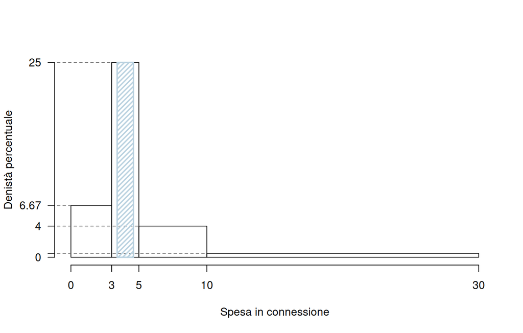

1.b **(Punti 3/105 $\rightarrow$ 0.9/31)** Qual è la percentuale di imprese che investe tra il 30-esimo percentile $x_{0.30}$ e e il 60-esimo percentile $x_{60}$?

$$\%(x_{0.30}<X<x_{0.60}) = (F(x_{0.60})-F(x_{0.30}))\times 100\% =
(0.60- 0.30)\times 100\%=30\%$$

1.c **(Punti 2/105 $\rightarrow$ 0.6/31)** La media è pari a $\bar x=5$, senza disegnare l’istogramma, che forma distributiva dobbiamo aspettarci?

1.d **(Punti 2/105 $\rightarrow$ 0.6/31)** Se $\{x_1,...,x_n\}$ è una serie di dati con media aritmetica $\bar x=\frac 1n\sum_i x_i=0.8$ e varianza $\sigma_X^2=\frac 1n\sum_i(x-\bar x)^2=2.25$. Posto
$$y_i = 1-x_i,~~\forall i=1,...,n$$
ricavare media aritmetica e varianza delle $\{y_1,...,y_n\}$.

$$\bar y = 1-\bar x = 0.2 ;~~~~\sigma_Y^2=(-1)^2\sigma_X^2=2.25$$

### Esercizio 2

2.a **(Punti 14/105 $\rightarrow$ 4.1/31)** Sia $X\sim N(1,2)$ e sia $Y\sim N(-1,2)$, $X$ e $Y$ indipendenti sia $A=\{X>0\}$, $B=\{X<1\}$ e $C=\{Y<1\}$. Calcolare $P(A\cap B\cap C)$.

2.b **(Punti 3/105 $\rightarrow$ 0.9/31)** , posto $W=(X+Y)/2$, calcolare $P(W<1|W>-1)$.

$$P(W<1|W>-1)=\frac{P(-1<W<1)}{P(W>-1)}=\frac{0.6827}{0.8413}=0.8114$$

2.c **(Punti 2/105 $\rightarrow$ 0.6/31)** Se $A$ e $B$ sono due eventi tali che $P(A)=0.2$, $P(B)=0.6$, e $P(A\cup B)=0.6$. Gli eventi $A$ e $B$ sono incompatibili? Perché?

No, perché se lo fossero
$$P(A\cup B)=P(A)+P(B)=0.8\ne 0.6$$

2.d **(Punti 2/105 $\rightarrow$ 0.6/31)** Sia $X$ na VC tale che $P(X\le-1)=0.1$ e $P(X>1)=0.1$, calcolare
$$P(X>-1|X\le 1)$$

$$\begin{eqnarray*}
P(X>-1|X\le 1) &=& \frac{P(\{X>-1\}\cap \{X\le
1\})}{P(X\le 1)}\\
&=& \frac{P(-1 < X \le 1)}{1- P(X> 1)}\\
&=& \frac{P(X\le 1)-P(X\le -1)}{0.9}\\
&=& \frac{0.8}{0.9}=0.8889
\end{eqnarray*}$$

### Esercizio 3

3.a **(Punti 14/105 $\rightarrow$ 4.1/31)** Da un’urna che contiene due bianche e due rosse si estrae 4 volte con reinserimento. Si vince se escono esattamente due bianche su quattro estrazione e si perde altrimenti. Si ripete il gioco per $n=100$ volte. Calcolare la probabilità di vincerà più di 40 volte.

la probabilità di vincere una partita è
$$\begin{eqnarray*}
P( X_i = 2 ) &=& \binom{ 4 }{ 2 } 0.5 ^{ 2 }(1- 0.5 )^{ 4
- 2 } \\ &=& 6 \times 0.5 ^{ 2 }(1- 0.5 )^{ 2 }
\\ &=& 0.375
\end{eqnarray*}$$

e quindi

**Teorema del Limite Centrale (somma di Bernoulli)**

Siano $X_1$,…,$X_n$, $n=100$ VC IID, tc $X_i\sim\text{Ber}(\pi=0.375)$$,\forall i$, posto:
$$S_n = X_1 + ... + X_n$$
allora:
$$\begin{eqnarray*}
S_n & \mathop{\sim}\limits_{a}& N(n\pi,n\pi(1-\pi)) \\
&\sim & N(100\cdot0.375,100\cdot0.375\cdot(1-0.375)) \\
&\sim & N(37.5,23.44)
\end{eqnarray*}$$
$$\begin{eqnarray*}
P( S_n > 40 )
&=& P\left( \frac { S_n - n\pi }{ \sqrt{n\pi(1-\pi)}
} > \frac { 40 - 37.5 }{\sqrt{ 23.44 }} \right) \\
&=& P\left( Z > 0.52 \right)
\\ &=& 1-P(Z< 0.52 )\\
&=& 1-\Phi( 0.52 ) \\ &=& 0.3015
\end{eqnarray*}$$

### Esercizio 4

4.a **(Punti 3/105 $\rightarrow$ 0.9/31)** La VAC Gamma, $X \sim \text{Gamma}(\alpha, \beta)$, è una VC continua, definita su $S_X = \mathbb{R}^+$, $\alpha > 0$ e $\beta > 0$, con densità che per $\alpha > 1$ assume una forma campanulare con asimmetria positiva, mentre per $\alpha = 1$ coincide con l’esponenziale e per $\alpha < 1$ è fortemente asimmetrica con una concentrazione di densità vicino allo zero. Il parametro $\beta$ controlla la dispersione. La distribuzione Gamma è usata per modellare tempi di attesa o grandezze cumulative sempre positive.

Si consideri un campione $X_1,\dots,X_n \sim \text{Gamma}(\alpha,\beta)$ IID. Si assuma noto il valore di $\beta$. Lo stimatore di massima verosimiglianza per $\alpha$ è

$$\hat\alpha = \frac{\bar X}{\beta}, \qquad \text{dove \( \bar X \) è la
media campionaria}$$

Sapendo che

$$E(\hat\alpha) = \alpha \qquad \text{e} \qquad V(\hat\alpha) =
\frac{\alpha}{n},$$

$\hat\alpha$ è consistente?

Poiché $\hat\alpha$ è corretto (cioè $E(\hat\alpha) = \alpha$) il suo $MSE$ coincide con la sua varianza $MSE(\hat\alpha)=V(\hat\alpha)$ e siccome

$$\lim_{n \to \infty} MSE(\hat\alpha)=\lim_{n \to \infty} V(\hat\alpha) =
\lim_{n \to \infty} \frac{\alpha}{n} = 0,$$

allora $\hat\alpha$ è **consistente**.

4.b **(Punti 3/105 $\rightarrow$ 0.9/31)** Cosa significa che uno stimatore è asintoticamente corretto?

4.c **(Punti 3/105 $\rightarrow$ 0.9/31)** Definire gli errori di primo e secondo tipo di un test statistico.

4.d **(Punti 3/105 $\rightarrow$ 0.9/31)** In uno studio su piccole imprese manifatturiere del Nord e del Centro Italia si è voluto verificare se la quota di imprese che ha adottato misure di efficientamento energetico fosse maggiore nel Nord.  
Nel campione, 35 imprese su 50 (il $70\%$) nel Nord e 30 su 50 (il $60\%$) nel Centro hanno dichiarato di aver adottato tali misure.

Posto a test
$$\begin{cases}
H_0: \pi_\text{Nord} = \pi_\text{Centro} \\
H_1: \pi_\text{Nord} > \pi_\text{Centro}
\end{cases}$$
si è ottenuto un $p_\text{value} = 0.147254$. Possiamo affermare che la proporzione di aziende del nord Italia che ha adottato misure di efficientamento sia maggiore di quella del centro Italia? Perché?

No, siccome il $p_\text{value}>0.05$ il $70\%$ del nord non è significativamente maggiore del $60\%$ del centro.

### Esercizio 5

In un’indagine comparativa condotta sui $n = 27$ paesi dell’Unione Europea, sono stati rilevati per ciascun paese la media annua di ore lavorate per addetto ($X$, in migliaia di ore) e il valore aggiunto per addetto ($Y$, in migliaia di Euro a parità di potere d’acquisto). Si vuole studiare l’associazione tra intensità del lavoro e produttività nei diversi contesti nazionali.

Sono state calcolate le seguenti statistiche:

$$\sum_{i=1}^{27} x_i = 43.49,\quad \sum_{i=1}^{27} y_i = 9.49,\quad
\sum_{i=1}^{27} x_i^2 = 70.84,\quad \sum_{i=1}^{27} y_i^2 = 4.35,\quad
\sum_{i=1}^{27} x_iy_i = 14.48$$

5.a **(Punti 14/105 $\rightarrow$ 4.1/31)** Stimare il modello di regressione lineare di $Y$ su $X$ e calcolare il residuo per la Francia, per la quale si è osservato $x_{\text{FR}} = 1.6943$, $y_{\text{FR}} = 0.3102$.

$$\begin{eqnarray*}
\bar x &=&\frac 1 n\sum_{i=1}^n x_i = \frac {1}{ 27
} 43.49 = 1.611 \\
\bar y &=&\frac 1 n\sum_{i=1}^n y_i = \frac {1}{ 27
} 9.49 = 0.3515 \\
\hat\sigma_X^2&=&\frac 1 n\sum_{i=1}^n x_i^2-\bar
x^2=\frac {1}{ 27 } 70.84 - 1.6107 ^2= 0.02922 \\
\hat\sigma_Y^2&=&\frac 1 n\sum_{i=1}^n y_i^2-\bar
y^2=\frac {1}{ 27 } 4.35 - 0.3515 ^2= 0.03757 \\
\text{cov}(X,Y)&=&\frac 1 n\sum_{i=1}^n x_i~y_i-\bar
x\bar y=\frac {1}{ 27 } 14.48 - 1.6107 \cdot 0.3515 = -0.02986 \\
\hat\beta_1 &=&
\frac{\text{cov}(X,Y)}{\hat\sigma_X^2} \\
&=& \frac{ -0.02986 }{ 0.02922 } = -1.022
\\
\hat\beta_0 &=& \bar y - \hat\beta_1 \bar x\\
&=& 0.3515 - (-1.0219) \times 1.6107 =
1.998
\end{eqnarray*}$$
$$\begin{eqnarray*}
\hat y_i &=&\hat\beta_0+\hat\beta_1 x_i=\\
&=& 1.998 + (-1.0219) \times 1.6943 = 0.2661 \\
\hat \varepsilon_i &=& y_i-\hat y_i\\
&=& 0.3102 - 0.2661 = 0.04406
\end{eqnarray*}$$

5.b **(Punti 3/105 $\rightarrow$ 0.9/31)** Interpretare il segno di $r$ e il valore di $r^2$.

$$\begin{eqnarray*}
r&=&\frac{\text{cov}(X,Y)}{\sigma_X\sigma_Y}=\frac{ -0.02986 }{
0.1709 \times 0.1938 }= -0.9012 \\r^2&=& 0.8121 > 0.75
\end{eqnarray*}$$
Il modello si adatta bene ai dati.

5.c **(Punti 2/105 $\rightarrow$ 0.6/31)** In un modello di regressione quanto vale la covarianza tra le i valori osservati di $X$, $x_1,...,x_n$ e i residui stimati $\hat\varepsilon_1,...,\hat\varepsilon_n$, $\text{cov}(\hat\varepsilon,X)$?

5.d **(Punti 2/105 $\rightarrow$ 0.6/31)** Definire il diagramma dei residui.

5.e **(Punti 2/105 $\rightarrow$ 0.6/31)** Se in un modello di regressione $r=-1$, cosa significa?

5.f **(Punti 14/105 $\rightarrow$ 4.1/31)** Testare l’ipotesi che il coefficiente angolare $\beta_1$ sia uguale a zero contro l’alternativa che sia diverso, per $\alpha=0.1,0.05,0.01,0.001$ e dare una valutazione approssimativa del $p_\text{value}$ (ad esempio il $p_\text{value}$ è minore di 0.001, compreso tra 0.05 e tra 0.01, ecc.).

$\fbox{A}$ FORMULAZIONE DELLE IPOTESI

$$\begin{cases}
H_0: \beta_1 = \beta_{1;H_0}=0 \\
H_1: \beta_1 \neq \beta_{1;H_0}=0
\end{cases}$$

$\fbox{B}$ SCELTA E CALCOLO STATISTICA-TEST, $T$ Test su un coefficiente di regressione: $\Rightarrow$ t-Test.

$$\begin{eqnarray*}
\hat{\sigma_\varepsilon}^2&=&(1-r^2)\hat\sigma_Y^2\\
&=& (1- 0.8122 )\times 0.0376 \\
&=& 0.0071 \\
S_\varepsilon^2 &=& \frac{n} {n-2}
\hat{\sigma_\varepsilon}^2\\
&=& \frac{ 27 } { 27 -2} \hat{\sigma_\varepsilon}^2 \\
&=& \frac{ 27 } { 27 -2} \times 0.0071 = 0.0076
\end{eqnarray*}$$

E quindi
$$\begin{eqnarray*}
V(\hat\beta_{1}) &=& \frac{\sigma_{\varepsilon}^{2}} {n
\hat{\sigma}^{2}_{X}} \\
\widehat{V(\hat\beta_{1})} &=& \frac{S_{\varepsilon}^{2}} {n
\hat{\sigma}^{2}_{X}} \\
&=& \frac{ 0.0076 } { 27 \times 0.0292 } = 0.0097 \\
\widehat{SE(\hat\beta_{1})} &=& \sqrt{ 0.0097 }\\
&=& 0.09849
\end{eqnarray*}$$

$$\begin{eqnarray*}
\frac{\hat\beta_{ 1 } - \beta_{ 1 ;H_0}} {\widehat{SE(\hat\beta_{ 1
})}}&\sim&t_{n-2}\\
t_{\text{obs}}
&=& \frac{ ( -1.022 - 0 )} { 0.09831 }
= -10.39 \, .
\end{eqnarray*}$$

$\fbox{C}$ CONCLUSIONE

Siccome $H_1$ è bilaterale, considereremo $\alpha/2$, anziché $\alpha$

$\alpha=0.1, 0.05, 0.01, 0.001$ e quindi $\alpha/2=0.05, 0.025, 0.005, 0.0005$

I valori critici sono

$t_{27-2;0.05}=1.7081$; $t_{27-2;0.025}=2.0595$; $t_{27-2;0.005}=2.7874$; $t_{27-2;0.0005}=3.7251$

Siccome $|t_\text{obs}|=10.3945>3.7251$, quindi **rifiuto** $H_0$ sotto all’1‰,

$p_\text{value}<0.001$, *estremamente significativo* $\fbox{***}$.

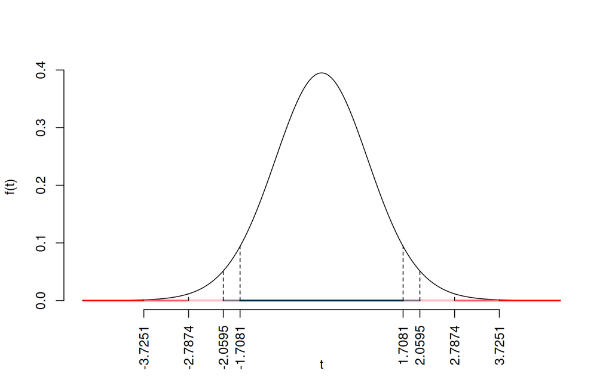

Il $p_{\text{value}}$ è

$$p_{\text{value}} =
P(|T_{27-2}|>|-10.39|)=2P(T_{27-2}>10.39)=1e-10$$

Attenzione il calcolo del $p_\text{value}$ con la $T$ è puramente illustrativo e non può essere riprodotto senza una calcolatrice statistica adeguata.
$$0 < p_\text{value}= 1e-10 \leq 0.001$$